# Calibrating Gene-Set Scores in Your Data

sparseGenSetCal

## The question this package answers

You have a gene set, a single-cell matrix, and a hypothesis that the set’s score tracks something – a cluster, a treatment, a clinical axis. You compute AUCell scores, you test the correlation, you get a p-value. Before you believe it, there is one question worth answering: **how much of that score was measured, and how much of it was the ranking filling in for genes the cell never expressed?**

That is not a rhetorical question, and its answer is computable in closed form. Every rank-based score asks where a gene sits among *all* genes in a cell. A cell that expresses fewer genes than the score’s rank ceiling has no count to place in the remaining positions, so those positions go to genes the cell never expressed, ordered by whatever rule the implementation uses to break ties. One such gene contributes, in expectation,

$$\tau(D) =
\frac{(m-D)(m-D+1)}{2\,m\,(G-D)},$$

with $m$ the rank ceiling, $G$ the panel size and $D$ the number of genes the cell detected. It is a function of the cell’s depth and not of the gene set – and depth tracks almost every biological axis one cares about. A score carried by that term will correlate with the axis for reasons that have nothing to do with the biology.

This vignette walks through the four steps that replace the null the data cannot support with one it can, on data small enough to run in a few seconds. Everything here is an export of the package, so you can paste it into your own script and point it at your matrix.

## A matrix to work with

`make_synthetic_matrix()` produces Poisson counts with a realistic gene-activity gradient – three orders of magnitude between the most and least active genes – and a depth distribution you control through `density`. Using your own data instead means passing the matrix and its gene names; nothing else changes.

```r
X <- make_synthetic_matrix(n_cells = 600, n_genes = 6000, density = 0.04,
                           seed = 11)
dim(X$matrix)
```

```
#> [1]  600 6000
```

The rank ceiling is a fraction of the panel, as in AUCell’s default. The cache holds each gene’s rank in each cell whenever that rank is at or below the ceiling, and zero otherwise; ranks above the ceiling contribute to none of the scores implemented here, so keeping them would only cost memory.

```r
rank_frac <- 0.05
ceiling <- as.integer(ceiling(rank_frac * ncol(X$matrix)))
cache <- rank_cache(X$matrix, X$genes, ceiling = ceiling, seed = 2024)
cache
```

```
#> <RankCache> 600 cells x 6000 cached genes (of 6000), ceiling 300, depth recorded
```

One number decides whether any of this matters, and it can be read off the depth distribution before a gene set is chosen: the ceiling divided by the median number of genes a cell detects. Below one, every rank inside the ceiling holds a measured count and the tie-break never enters the score. Above one, the slots the cell cannot fill are given to genes it never expressed.

```r
median_depth <- stats::median(cache$depth)
data.frame(quantity = c("max_rank", "median genes detected", "ratio"),
           value = c(ceiling, median_depth, round(ceiling / median_depth, 2)))
```

```
#>                quantity  value
#> 1              max_rank 300.00
#> 2 median genes detected 238.50
#> 3                 ratio   1.26
```

Here the ratio is above one, which is the regime the whole framework is about. It is also the common one: a shallow cell in a large panel cannot fill a top-5% block with genes it detected.

## Step 1: how much of the score was never measured

`sparsity_report()` needs the cache and the set, and nothing else. It reports the share of cells scoring exactly zero, the detection profile of the set, and – given the depth vector, which the cache carries – the share of the set’s chance of entering the score that the tie-break supplies.

The thresholds the verdict uses are visible in the table below, which walks a set through detection rates from 0.2% to 80%. Real gene sets are not more exotic than this: a set of transcription factors and a set of ribosomal proteins are the two ends of it.

```r
set_at_detection <- function(target, n = 10) {
    cache$genes[order(abs(cache$detection - target))][seq_len(n)]
}
gradient <- function(target) {
    r <- sparsity_report(cache, set_at_detection(target), rank_frac = rank_frac)
    v <- verdict(r)
    data.frame(detection = target,
               median_detection = r$median_detection,
               zero_rate = r$observed_zero_rate,
               share = r$tie_break_share,
               verdict = v$verdict,
               severity = v$severity)
}
watch <- function(d) {
    d$median_detection <- round(d$median_detection, 3)
    d$zero_rate <- round(d$zero_rate, 3)
    d$share <- round(d$share, 3)
    d
}
tb <- do.call(rbind, lapply(c(0.002, 0.005, 0.01, 0.02, 0.05, 0.15, 0.4, 0.8),
                            gradient))
watch(tb)
```

```
#>   detection median_detection zero_rate share                         verdict
#> 1     0.002            0.002     0.873 0.876                NOT_IDENTIFIABLE
#> 2     0.005            0.005     0.858 0.701                NOT_IDENTIFIABLE
#> 3     0.010            0.010     0.805 0.539                NOT_IDENTIFIABLE
#> 4     0.020            0.020     0.747 0.366                NOT_IDENTIFIABLE
#> 5     0.050            0.050     0.548 0.183                NOT_IDENTIFIABLE
#> 6     0.150            0.150     0.210 0.063 INTERPRETABLE_WITH_MATCHED_NULL
#> 7     0.400            0.401     0.015 0.017 INTERPRETABLE_WITH_MATCHED_NULL
#> 8     0.800            0.741     0.000 0.004 INTERPRETABLE_WITH_MATCHED_NULL
#>   severity
#> 1     HIGH
#> 2     HIGH
#> 3     HIGH
#> 4     HIGH
#> 5     HIGH
#> 6 MODERATE
#> 7 MODERATE
#> 8 MODERATE
```

Read it down the `share` column: at 0.2% detection most of the set’s chance of entering the score is tie-break, and at 15% almost none of it is – an order of magnitude of movement over rows where the only thing that changed is how often the cells detected the set. No pathway, no co-expression, no biology moved.

The verdict is also not a property of the gene set alone. Rerun this on a dataset with deeper cells and the same rows shift right, because the tie-break enters the score only where a cell’s depth falls short of the ceiling.

The rest of the vignette uses a set from the middle of that table, where the answer is genuinely contested.

```r
gene_set <- set_at_detection(0.02)
```

## Step 2: a null the data supports

A permutation test that shuffles cells answers “is this score different from what the same cells would give by chance”, which is not the question. The question is whether the *set* carries information beyond its detection profile, so the null has to be drawn from genes with the same profile.

`construct_expression_matched_null()` draws replacement sets from the detection-rate stratum of each gene of the set, excluding the whole query set from the pool. It reports the composition it achieved, because a null that silently failed to match is worse than no null at all.

```r
built <- construct_expression_matched_null(cache, gene_set, n_sets = 20,
                                           seed = 42)
data.frame(
    quantity = c("target detection", "null detection", "ratio",
                 "worst per-set gap", "genes shared with the query",
                 "draws that had to relax the pool", "status"),
    value = c(round(built$target_detection, 4),
              round(built$null_detection, 4),
              round(built$detection_ratio, 4),
              round(built$worst_detection_gap, 4),
              built$max_overlap, built$draw_relaxations, built$status))
```

```
#>                           quantity value
#> 1                 target detection  0.02
#> 2                   null detection  0.02
#> 3                            ratio     1
#> 4                worst per-set gap     0
#> 5      genes shared with the query     0
#> 6 draws that had to relax the pool     0
#> 7                           status  PASS
```

Two of those columns are the ones to look at. `max_overlap` has to be zero: a null set that reuses a gene of the query is not a null, it is the observation with extra steps. And `status` is `FAIL` when the pool could not supply a set close enough in detection rate, which happens when the query is so sparse that nothing in the background resembles it – a real finding about the data, not a hiccup in the function.

Now score the observation and its null on the same cells and correlate both against an axis. The axis here is the depth itself, which is the worst case and therefore the honest one to demonstrate with.

```r
axis <- cache$depth
cal <- compute_calibrated_score(cache, gene_set,
                                null_genes = built$null_genes,
                                axis = axis)
str(cal$summary[c("observed", "null_mean", "null_sd", "p_value")])
```

```
#> List of 4
#>  $ observed : num -0.124
#>  $ null_mean: num -0.101
#>  $ null_sd  : num 0.0387
#>  $ p_value  : num 0.333
```

## Step 3: what the rule you were going to use actually does

The other silent source of false positives is the cutpoint. Choosing the cutpoint that best separates the outcome and then testing it as if it had been chosen in advance is the standard move in this literature, and it is anticonservative in a way that is easy to measure. `cutpoint_fpr()` permutes the outcome, re-applies the rule, and counts how often it declares a significance it was never entitled to.

```r
outcome <- axis > stats::median(axis)
rules <- c("median", "optimum")
fprs <- lapply(rules, function(m) {
    cutpoint_fpr(cal$observed, outcome, n_perm = 300, method = m, seed = 7)
})
names(fprs) <- rules
data.frame(rule = rules,
           fpr = round(vapply(fprs, function(f) f$fpr, 0), 3),
           observed_p = signif(vapply(fprs, function(f) f$observed_p, 0), 2),
           cutpoint = signif(vapply(fprs, function(f) f$observed_cutpoint, 0), 3))
```

```
#>            rule   fpr observed_p cutpoint
#> median   median 0.040      0.110  0.00000
#> optimum optimum 0.143      0.082  0.00829
```

The median rule holds its level: its false-positive rate is about 0.05, as a rule that never looked at the outcome should. The optimal rule does not, and the multiple is what the outcome-driven cutpoint costs on this score. Both rules report the *same* data on the same cells; they differ only in whether the cutpoint was chosen by looking at the outcome. `n_perm = 300` here for speed; the default is 1000.

## Step 4: the whole checklist in one call

`diagnostic_checklist()` runs all four steps on one gene set and returns a serialisable object. This is the function to keep in a pipeline.

```r
check <- diagnostic_checklist(cache, gene_set, axis = axis, n_perm = 300,
                              label = "example set")
check$overall_verdict
```

```
#> [1] "NOT_IDENTIFIABLE"
```

```r
check$severity
```

```
#> [1] "HIGH"
```

```r
cat(check$reasons, sep = "\n")
```

```
#> 75% of cells score exactly zero, so most cells carry no information about the set
#> the observed zero rate departs from the independent-draw expectation by +15 percentage points, so the set is not behaving like an independent draw
#> the association was not tested against an expression-matched null
#> no independent cohort was tested
```

The verdict is deliberately blunt. `NOT_IDENTIFIABLE` means the score cannot carry the cell-level claim being made about it, whatever the p-value was; `INTERPRETABLE_WITH_MATCHED_NULL` means the association may be real but every test of it has to be run against a matched null, and the object carries the one that was constructed. `to_json()` writes it out.

```r
path <- tempfile(fileext = ".json")
to_json(check, path)
cat(substr(readLines(path), 1, 60), sep = "\n")
```

```
#> {
#>   "label": "example set",
#>   "n_cells": 600,
#>   "n_genes_total": 6000,
#>   "max_rank": 300,
#>   "step1_sparsity": {
#>     "percent_zero": 74.66666667,
#>     "structural_zero_rate": 0.59873694,
#>     "zero_rate_excess": 0.14792973,
#>     "n_present": 10,
#>     "n_missing": 0,
#>     "frac_above_floor": 1,
#>     "detection_floor": 0.005,
#>     "mean_detection": 0.02,
#>     "criterion": "tie_break_share",
#>     "severity": "HIGH",
#>     "recommendation": "USE_MATCHED_NULL",
#>     "tie_break_share": 0.3662288,
#>     "mean_inclusion": 0.03155713
#>   },
#>   "step2_null_construction": {
#>     "null_pool_size": 4795,
#>     "det_floor": 0.005,
#>     "target_detection": 0.02,
#>     "null_detection": 0.02,
#>     "detection_ratio": 1,
#>     "expression_ratio": 0.99471074,
#>     "ks_test_pvalue": 1,
#>     "ks_statistic": 3.46944695e-17,
#>     "max_overlap": 0,
#>     "n_from_query": 0,
#>     "status": "PASS"
#>   },
#>   "step3_false_positive_rate": {
#>     "attempted": false,
#>     "note": "no cutpoint rule was declared; step 3 measures
#>   },
#>   "step4_external_replication": {
#>     "attempted": false,
#>     "replication_cohorts": 0,
```

[output cut: 25 more lines]

```
#>     "median_detected": 238.5,
#>     "depth_ratio": 1.25786164,
#>     "tau_axis_rho": -0.99011069,
#>     "tau_sd": 0.00317626,
#>     "tau_range": [0, 0.01855128],
#>     "depth_axis_rho": 1,
#>     "detection_mean": 0.02,
#>     "gamma": 0.98,
#>     "implied_rho": -0.97030848,
#>     "mean_inclusion": 0.03155713,
#>     "tie_break_share": 0.3662288,
#>     "chance_band": 0.08021746,
#>     "verdict": "CONFOUNDED"
#>   }
#> }
```

```r
unlink(path)
```

## What changes and what does not

The framework does not tell you that your association is false. It tells you what part of the evidence for it came from the measurement and what part came from the ranking, which is a distinction the conventional analysis does not draw. Three things follow, in the order they are usually needed:

1. **Report the share.** A tie-break share of 0.6 means that 60% of the set’s chance of entering the score comes from genes the cell did not express. That sentence belongs in the results whether or not it changes the conclusion.
2. **Replace the null.** Every test of the association – correlation, group difference, survival – should be run against expression-matched draws, and the p-value reported from that distribution rather than from the cells.
3. **Match the regime across cohorts.** A replication in a dataset with a different depth distribution tests a different score. `comparability_report()` reports whether two panels place the same set on the same scale before you read a replication failure as a biological disagreement.

One thing this does *not* license is treating every sparse set as uninformative. A set can be sparse and still carry signal: the split in `score_decomposition()` separates the two contributions cell by cell, and if the detected part is doing the work, the sparsity is a caveat and not a refutation.

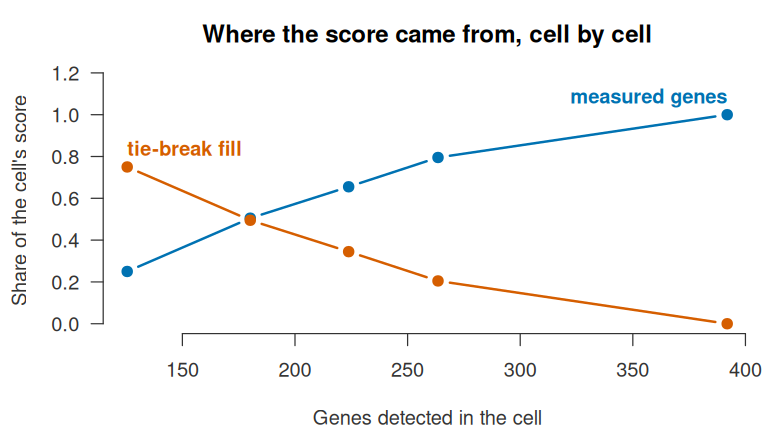

```r
split <- score_decomposition(cache, gene_set, X$matrix > 0,
                             max_rank = ceiling)
# The cells that score at all, in fifths of depth, each point the mean of its
# fifth.  Two things are being kept out of the picture: the three-quarters of
# cells whose score is exactly zero, which carry no rank information either
# way, and the cell-to-cell spread within a fifth, which is wide enough to hide
# the trend if every cell were drawn.
scoring <- split$total > 0
tie_share <- split$tie_break[scoring] / split$total[scoring]
depth <- cache$depth[scoring]
fifth <- as.integer(cut(depth, stats::quantile(depth, seq(0, 1, 0.2)),
                        labels = FALSE, include.lowest = TRUE))
by_fifth <- function(v) as.numeric(tapply(v, fifth, mean))
okabe <- c("#0072B2", "#D55E00")
op <- par(bty = "n", mar = c(4.1, 4.3, 2.8, 1.2), las = 1,
          col.axis = "#333333", col.lab = "#333333", fg = "#333333")
plot(by_fifth(depth), 1 - by_fifth(tie_share), type = "b", pch = 19, lwd = 2,
     col = okabe[1], ylim = c(0, 1.18),
     xlab = "Genes detected in the cell", ylab = "Share of the cell's score",
     main = "Where the score came from, cell by cell")
lines(by_fifth(depth), by_fifth(tie_share), type = "b", pch = 19, lwd = 2,
      col = okabe[2])
# Labelled at opposite ends: the curves cross, so labels placed at the same
# depth would sit on top of each other.  The offsets are in the direction the
# label has room in, so neither runs off the margin.
n <- length(by_fifth(depth))
text(by_fifth(depth)[1], by_fifth(tie_share)[1], "tie-break fill",
     col = okabe[2], adj = c(0, -0.75), font = 2)
text(by_fifth(depth)[n], 1 - by_fifth(tie_share)[n], "measured genes",
     col = okabe[1], adj = c(1, -0.75), font = 2)
```

```r
par(op)
```

The orange curve is the part of the score that the tie-break supplied. In the shallowest fifth of the cells that score at all it is three quarters of the score, and in the deepest fifth it is nothing – which is exactly what makes it a confound, since it is a monotone function of depth and depth is rarely the variable of interest. The blue curve is the part the cells measured. Averaged over the set, the orange is the `tie_break_share` of the table above.

## Reproducibility and where the numbers come from

Every function that draws anything takes a `seed`, and the defaults are stated in `DEFAULT_CONFIG`. The tie-break deserves a note of its own. It is not a draw from the random number generator: it is a key computed from the cell index, the gene index and the seed, so the cache is identical whatever `chunk` is used and identical to the Python reference implementation of the same framework, to the integer. That is what lets the two implementations be tested against each other rather than against each other’s statistics.

```r
a <- rank_cache(X$matrix, X$genes, ceiling = ceiling, chunk = 400)
b <- rank_cache(X$matrix, X$genes, ceiling = ceiling, chunk = 37)
identical(a$clipped, b$clipped)
```

```
#> [1] TRUE
```

The full derivation, the rates the framework was calibrated on and the comparison with the conventional analyses are in the accompanying manuscript. `citation("sparseGenSetCal")` and the package documentation give the entry points; `?sparsity_report`, `?construct_expression_matched_null` and `?diagnostic_checklist` are the three to read first.